# team

Connor Toliver; @connortoliver / Haley Humphries; @haley22

2/26/2020

# General Social Survey Data Exploration

```r
dat <- readxl::read_xls('GSS.xls')
```

```r
names(dat) <- c('year', 'happiness', 'party', 'sex', 'divorced', 'marital', 'self-emp', 'workstat', 'id', 'ballot')
dat <- dat[1:nrow(dat)-1,] # Removing last extraneous line in dataframe
dat <- na.omit(dat) # Remove all rows with null values
library('ggplot2')
```

### #1. How does the happiness of a respondent relate to the marriage status?

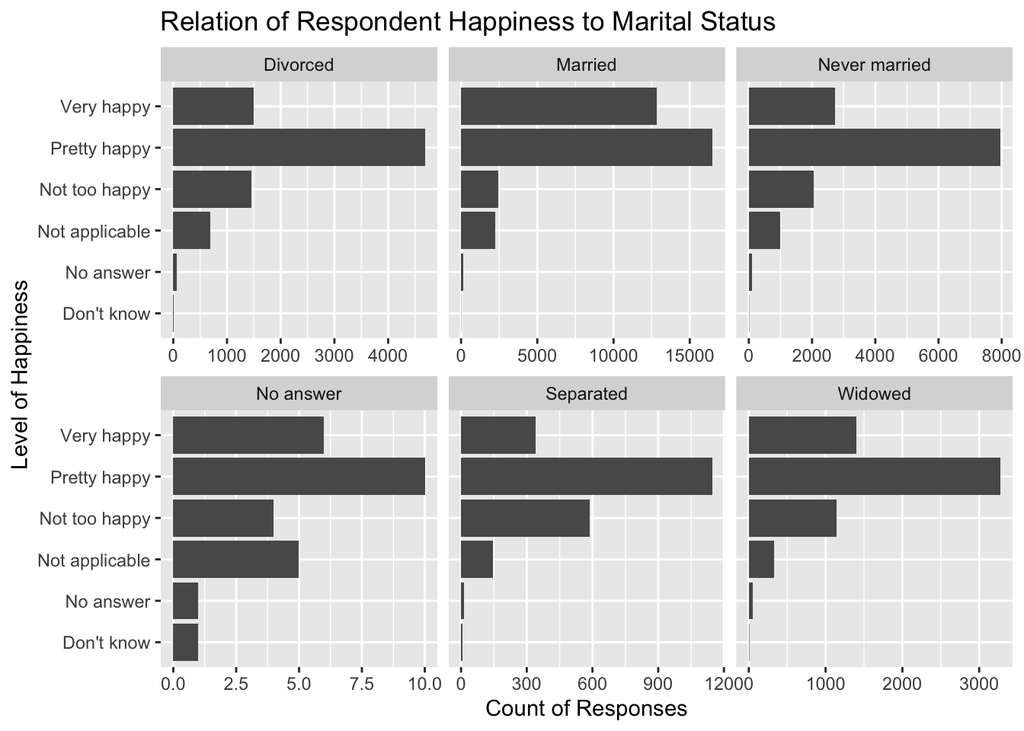

```r
ggplot(dat, aes(x=happiness)) +
  geom_bar() +
  facet_wrap(~marital, scales='free_x') +
  coord_flip() +
  xlab('Level of Happiness') +
  ylab('Count of Responses') +
  ggtitle('Relation of Respondent Happiness to Marital Status')
```

According to the graphs, married respondents have a much higher count of `very happy` responses. In comparison, other marital statuses have a much smaller proportion of very happy responses. Married responses also have less `not too happy` responses than the other marital statuses. Surprisingly, never married and divorced statusres have a similar proportion of responses; however, never married has a slightly higher proportion of `very happy` responses. It appears that the respondents are married or have been married. Not marrying, separating, or divorcing seems to make respondents unhappier.

### #2. Does the sex of the respondent affect the relationship you found in Q1?

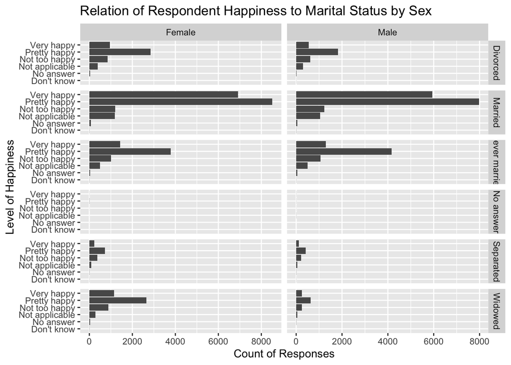

```r
ggplot(dat, aes(x=happiness)) +
  geom_bar() +
  facet_grid(marital~sex, scales='free_x') +
  coord_flip() + xlab('Level of Happiness') +
  ylab('Count of Responses') +
  ggtitle('Relation of Respondent Happiness to Marital Status by Sex')
```

The sex of the respondents doesn’t affect the relationship much at all; the proportions remain almost or practically the same. This could tell us that marital status affects the happiness of men and women similarly.

### #3. How does the happiness of a respondent relate to the political party affiliation?

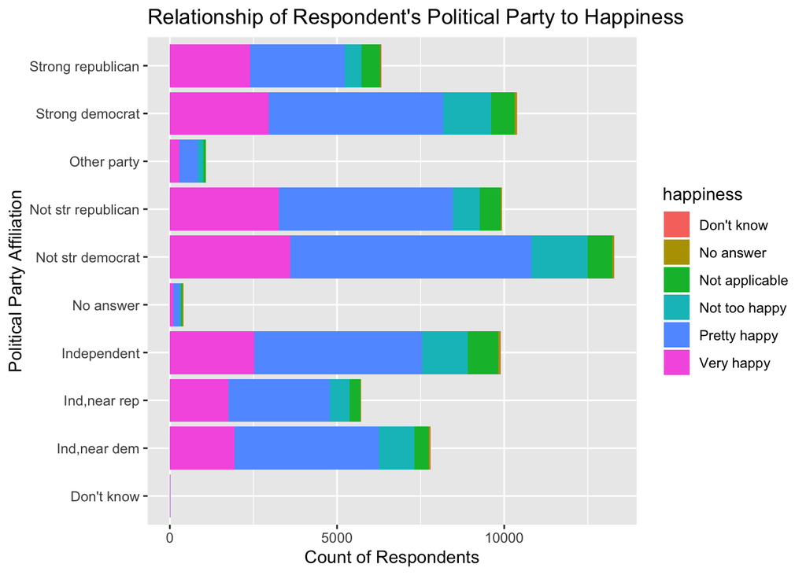

```r
ggplot(dat, aes(x =party)) +
  geom_bar(aes(fill=happiness)) +
  coord_flip() +
  ylab('Count of Respondents') +
  xlab('Political Party Affiliation') +
  ggtitle('Relationship of Respondent\'s Political Party to Happiness')
```

From this plot we can see that the political parties are about even in all the different levels of `happiness` but it also could depend on how many there are in each party We can see there are very few for “Other party” so that explains why there aren’t many of those for the different levels of `happiness`.

### #4. How has the ratio of men and women in various work statuses changed from 1980 until 2010?

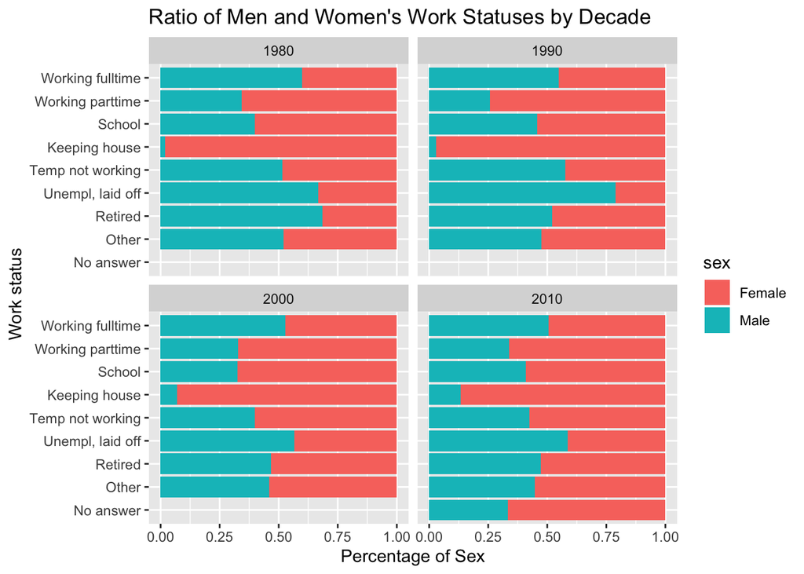

```r
dat3 <- dat[dat$year %in% c(1970, 1980, 1990, 2000, 2010), ]
dat3$workstat <- factor(dat3$workstat, c('No answer', 'Other', 'Retired', 'Unempl, laid off', 'Temp not working', 'Keeping house', 'School', 'Working parttime', 'Working fulltime'))

ggplot(dat3, aes(x=workstat, fill=sex)) +
  geom_bar(position='fill') +
  coord_flip() + facet_wrap(~year) +
  xlab('Work status') +
  ylab('Percentage of Sex') +
  ggtitle('Ratio of Men and Women\'s Work Statuses by Decade')
```

The ratio of men and women’s work statuses has remained largely the same from 1980 until 2010. Most notably is that more women are working full time, and more men are keeping house. This makes sense, as gender roles are becoming more blurred as time goes on (such as men being the breadwinner and women being the primary caregiver and housekeeper). What’s also interesting to note is that the ratio of retired men and women has gone from being primarily men to being primarily women. Perhaps women stop working earlier than men could explain this.

### #5. How does the happiness of self-employed men and women compare a decade apart from 2008 and 2018?

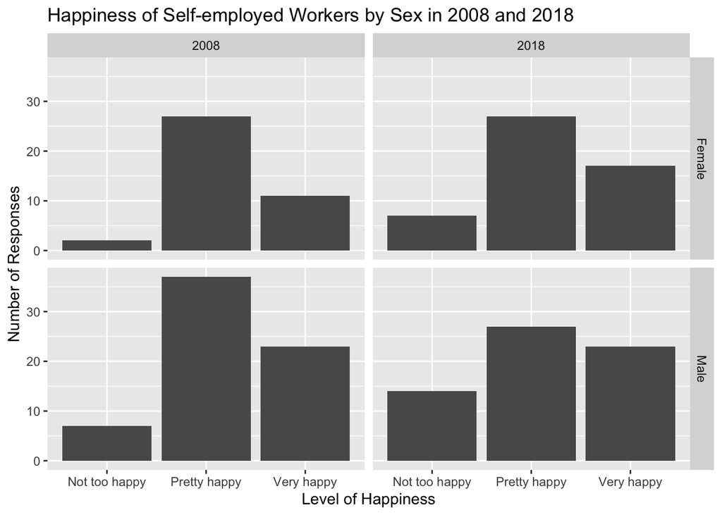

```r
dat2 <- dat[dat$`self-emp` == 'Self-employed' & dat$year == c(2008, 2018), ]
ggplot(dat2, aes(x=happiness)) +
  geom_bar() +
  facet_grid(dat2$sex~dat2$year) +
  xlab('Level of Happiness') +
  ylab('Number of Responses') +
  ggtitle('Happiness of Self-employed Workers by Sex in 2008 and 2018')
```

The biggest observation here is that self-employed men have become decreasingly happy. The number of respondens who selected `not too happy` about doubled from 2008 to 2018, and the number of `pretty happy` respondents decreased a fair aamount. Self-employed women also saw an increase of `not too happy` responses, but also saw a sizable increase in `very happy` responses as well. Overall, the resepondents appear to b generally happy and have a similar proportion of happiness levels. It would be interesting to see this graph in 10 more years, to see if the `not too happy` levels have increased even more.

### #6. Compare male and female divorces by political party.

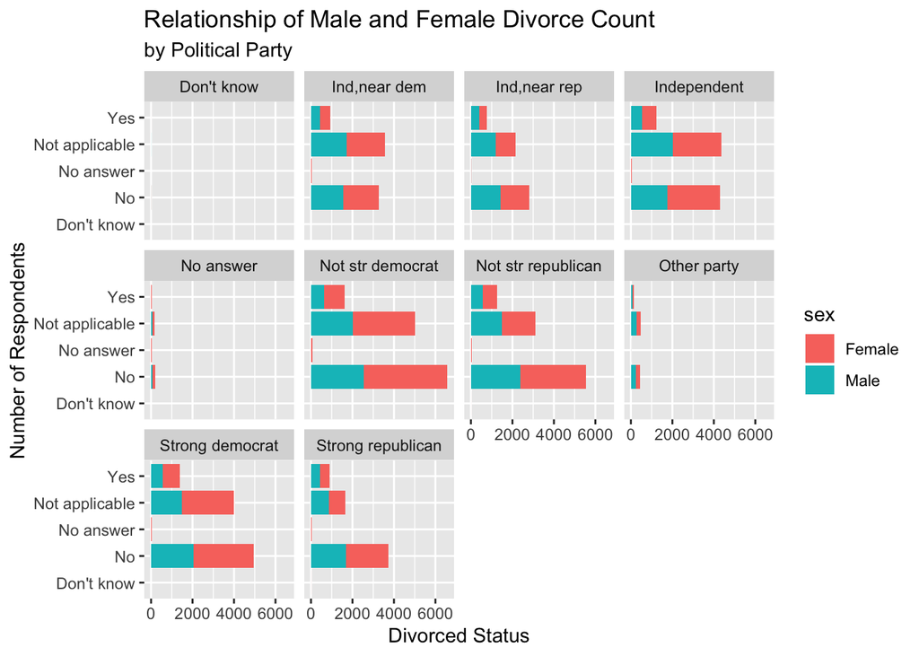

```r
ggplot(dat, aes(x = divorced)) +
  geom_bar(aes(fill=sex)) +
  facet_wrap(~party) +
  coord_flip() +
  xlab('Number of Respondents') +
  ylab('Divorced Status') +
  ggtitle('Relationship of Male and Female Divorce Count', subtitle='by Political Party')
```

From these plots we can see that most people are either not divorced or it doesn’t apply to them. It doesn’t seem to be very different among sex and political party aside from the count for the political parties. Thus, political party affiliation seem to have very little effect on whether a respondent has been divorced or not.

### #7. Compare happiness and work status.

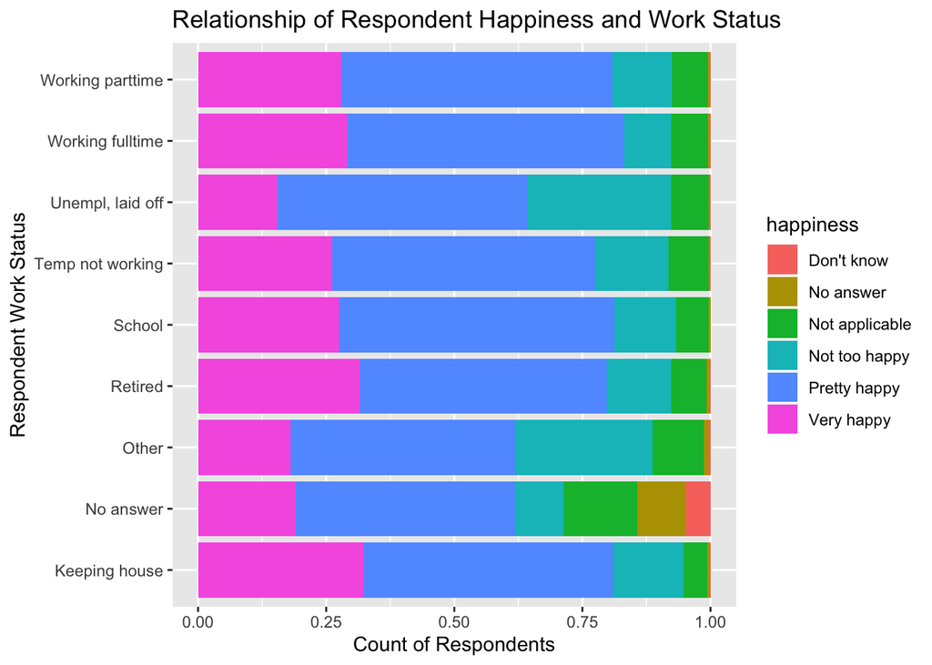

```r
ggplot(dat, aes(x = workstat, fill=happiness)) +
  geom_bar(position='fill') +
  xlab('Respondent Work Status') +
  ylab('Count of Respondents') +
  ggtitle('Relationship of Respondent Happiness and Work Status') +
  coord_flip()
```

Most respondents with some sort of job appear to have a similar level of responses for `very happy` and `pretty happy`. However, it’s clear that respondents who were unemployed or laid off had a much higher ratio of `not too happy` respondents. This is somewhat expected, as it can be quite a stressful position.